# 12 - Random Forests

## 1.4 Partial Dependence Plots (PDPs)

Partial dependence plots (PDPs) help us understand how a single predictor (or a pair of predictors) influences the model’s predictions, while averaging out the effects of all other predictors.

- For regression models, the y-axis shows the average predicted outcome as the predictor changes.
- For classification models, the y-axis typically shows the average predicted probability of the positive class.
- PDPs are useful for interpreting “black box” models like random forests, since they highlight nonlinear effects and interactions that may not be obvious from variable importance alone.

In short, PDPs answer: *If we vary one predictor, holding everything else constant on average, how do predictions change?*

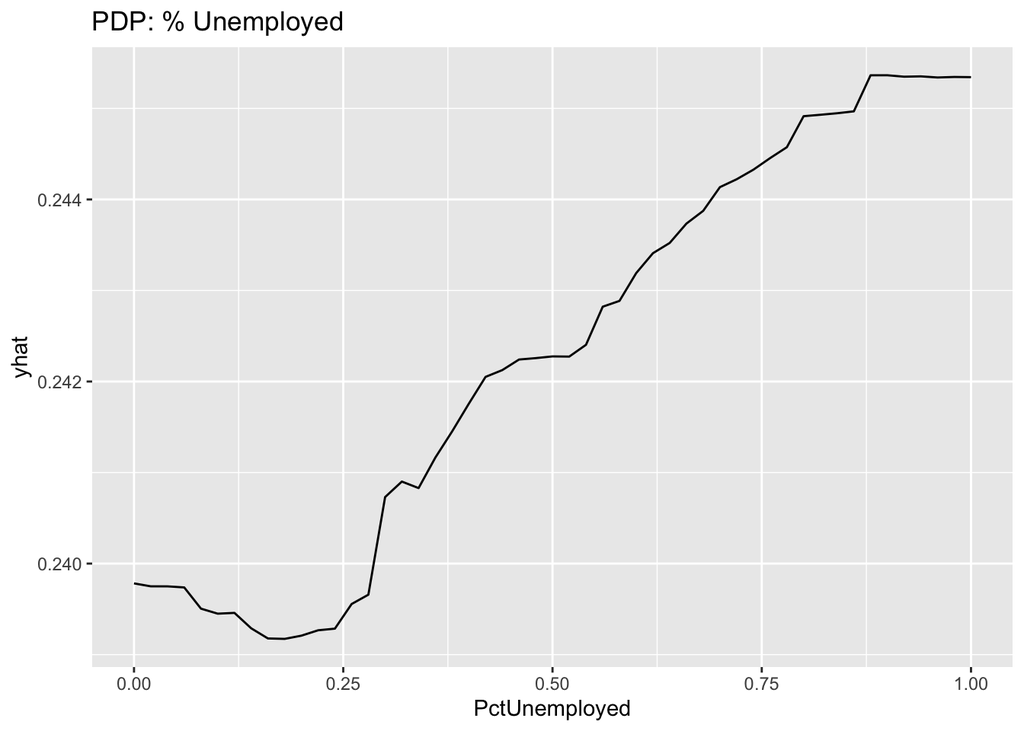

```r
p1 <- partial(rf_reg, pred.var = "PctUnemployed", train = train)
autoplot(p1, main = "PDP: % Unemployed")
```

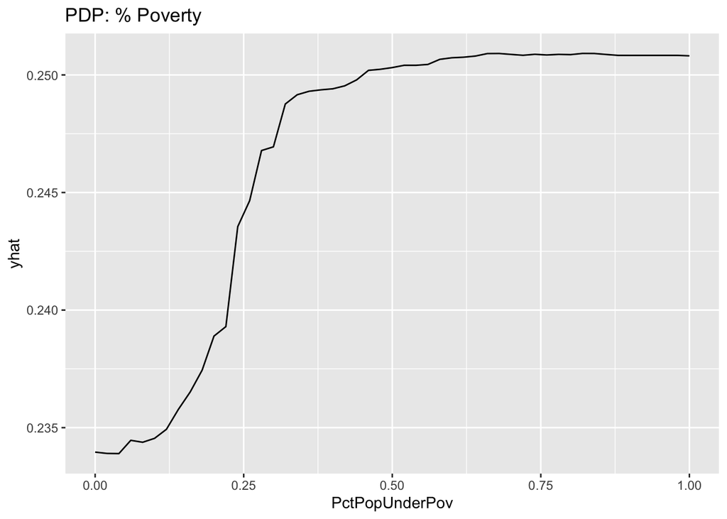

```r
p2 <- partial(rf_reg, pred.var = "PctPopUnderPov", train = train)
autoplot(p2, main = "PDP: % Poverty")
```

# 2 Random Forests for Classification

We now turn to the Pima Indians Diabetes dataset.

```r
PimaIndiansDiabetes <- read_csv("pima.indians.diabetes3.csv")
pima <- na.omit(PimaIndiansDiabetes) |>
  rename(diabetes = class) |>
  mutate(diabetes = as.factor(diabetes)) |>
  select(-classdigit)

set.seed(735)
train_index <- createDataPartition(pima$diabetes, p = 0.7, list = FALSE)
train <- pima[train_index, ]
test  <- pima[-train_index, ]
```

## 2.1 Fit Random Forest Classifier

First, let’s just fit for a fixed `mtry` and number of trees.

```r
rf_class <- randomForest(diabetes ~ ., data = train,
                         mtry = 3, ntree = 500, importance = TRUE)
rf_class
```

```
Call:
 randomForest(formula = diabetes ~ ., data = train, mtry = 3,      ntree = 500, importance = TRUE)
               Type of random forest: classification
                     Number of trees: 500
No. of variables tried at each split: 3

        OOB estimate of  error rate: 22.52%
Confusion matrix:
         diabetic normal class.error
diabetic       74     50   0.4032258
normal         34    215   0.1365462
```

## 2.2 Cross-validation to select mtry with caret

```r
set.seed(123)

# Define training control for 10-fold CV
ctrl <- trainControl(method = "cv", number = 10,
                     classProbs = TRUE,
                     summaryFunction = twoClassSummary)

# Train random forest model with CV to tune mtry
rf_caret <- train(diabetes ~ .,
                  data = pima,
                  method = "rf",
                  metric = "ROC",   # use AUC as performance measure
                  trControl = ctrl,
                  tuneGrid = data.frame(mtry = 1:7)) # grid of mtry values

rf_caret
```

```
Random Forest

532 samples
  7 predictor
  2 classes: 'diabetic', 'normal'

No pre-processing
Resampling: Cross-Validated (10 fold)
Summary of sample sizes: 479, 478, 478, 479, 478, 480, ...
Resampling results across tuning parameters:

  mtry  ROC        Sens       Spec
  1     0.8355552  0.5297386  0.8870635
  2     0.8346365  0.5866013  0.8785714
  3     0.8355846  0.5977124  0.8673016
  4     0.8341294  0.5977124  0.8618254
  5     0.8327614  0.5924837  0.8814286
  6     0.8273575  0.6035948  0.8562698
  7     0.8274853  0.5983660  0.8617460

ROC was used to select the optimal model using the largest value.
The final value used for the model was mtry = 3.
```

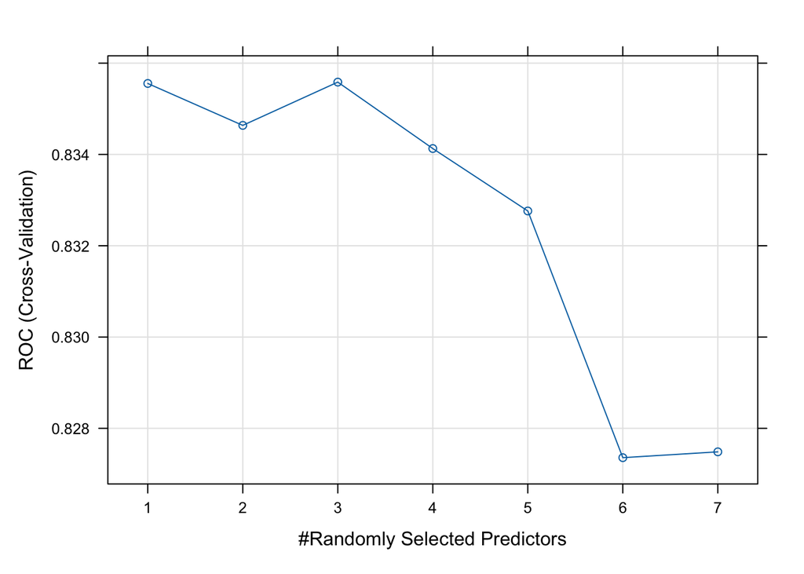

```r
plot(rf_caret)
```

## 2.3 Variable Importance for Final Model

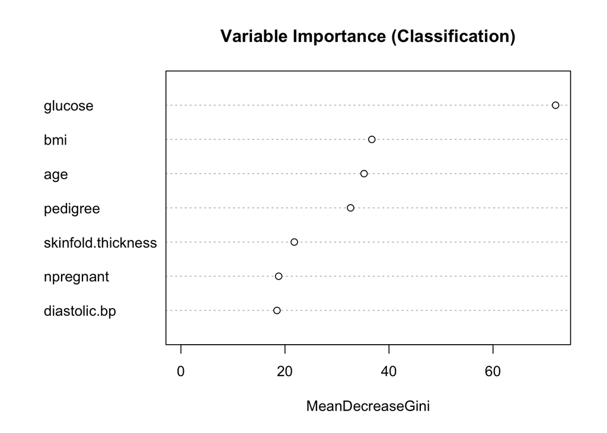

```r
rf_finalModel <- rf_caret$finalModel
varImpPlot(rf_finalModel, main = "Variable Importance (Classification)")
```